# assignment2

Daniel Vogel

1/30/2020

## Assignment 2: Beaver Body Temperatures

The built in dataframe, **beaver1**, tracks the body temperature of a beaver over approximately 20 hours in 10 minute intervals. There are 4 columns: *day*, *time*, *temp*, *activ*

### Summary beaver1

```
##       day             time             temp           activ
##  Min.   :346.0   Min.   :   0.0   Min.   :36.33   Min.   :0.00000
##  1st Qu.:346.0   1st Qu.: 932.5   1st Qu.:36.76   1st Qu.:0.00000
##  Median :346.0   Median :1415.0   Median :36.87   Median :0.00000
##  Mean   :346.2   Mean   :1312.0   Mean   :36.86   Mean   :0.05263
##  3rd Qu.:346.0   3rd Qu.:1887.5   3rd Qu.:36.96   3rd Qu.:0.00000
##  Max.   :347.0   Max.   :2350.0   Max.   :37.53   Max.   :1.00000
```

```
## [1] "The first 5 entries"
```

```
##   day time  temp activ
## 1 346  840 36.33     0
## 2 346  850 36.34     0
## 3 346  900 36.35     0
## 4 346  910 36.42     0
## 5 346  920 36.55     0
```

```
## [1] "The last 5 entries"
```

```
##     day time  temp activ
## 110 347  300 36.86     0
## 111 347  310 36.88     0
## 112 347  320 36.93     0
## 113 347  330 36.97     0
## 114 347  340 37.15     1
```

## Plotting the Temp Column

> This was alot harder than I expected!  
> Since the “time” column in the beaver1 dataframe goes from 840..2350..0..340, it is not possible to simply plot time,temp. You would have to convert time into a sequence of numbers that increases.

Instead, I used the observation# as the x axis. This is not explicitly a column in beaver1. The x-axis was created with a vector x from 1..#observations. i.e. 1 2 3. ..114 For the y-axis used the “temp” column from the beaver1 dataframe.

> DANGER Will Rogers!!

This does not work if you use the syntax: y<-beaver1[“temp”]

Plot spits out an error, **“Error in xy.coords(x, y, xlabel, ylabel, log) : ‘x’ and ‘y’ lengths differ”**

This is because “x” is a vector class and the “y” column is a sub-dataframe. Plot needs x,y to be the same type.  
To create the y-axis, use the [[*]*column*] syntax. i.e. y<-beaver1[[“temp”]] The [[]] converts the column to a vector. Now x,y are both vector type.

The command to plot is then: plot(x,y,type=“l”)

```
## [1] "Observations: 114"
```

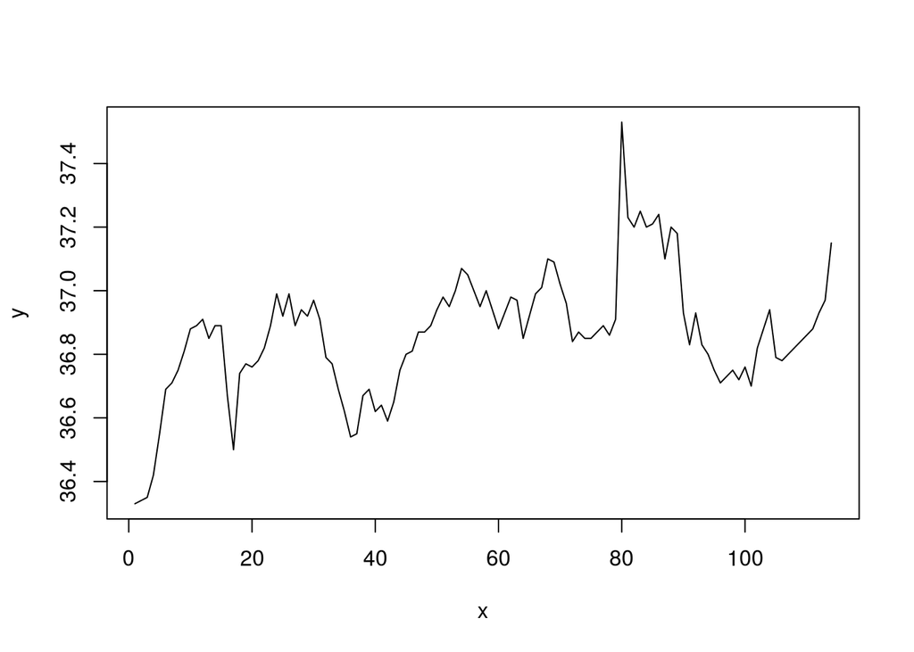